#### Dragos Ailoae

2021-11-01

# Intro to Hypothesis Testing

When we draw a conclusion from a significance test, we hope our conclusion will be correct. Because the sample is random, the test statistic, however defined, is also random. The same test procedure can lead to different conclusions in different samples. As such, there are two ways such a procedure can be in error: We can reject the null hypothesis when it's actually true, known as a Type I error, or we can fail to reject a false null hypothesis, which is a Type II error.

#### Definition:

Type I error: Reject a true $H_{0}$  
Type II error: Fail to reject a false $H_{0}$.

In other words, if we reject $H_{0}$ when $H_{0}$ is true, we have committed a Type I error. If we fail to reject $H_{0}$ when $H_{0}$ is false, we have committed a Type II error.

### Type I and Type II Errors: How to Remember Which is Which

$\quad$

$\quad$ $H_0$: You are not pregnant

$H_a$: You are pregnant

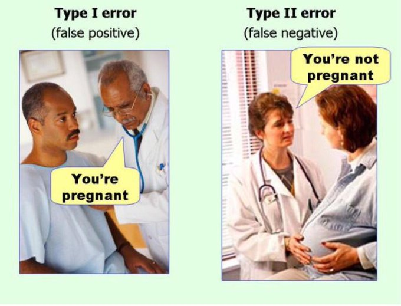

In econometrics, the most common hypothesis test is whether a regression parameter is significantly different from 0 (i.e. does the independent variable have an effect on the dependent variable?).

$H_0$: $\beta=0$ (Independent variable has no effect)

$H_a$: $\beta\neq 0$ (Independent variable has an effect)

### The Confusion Matrix and Statistical Power

Confusion Matrix

Power of a Test

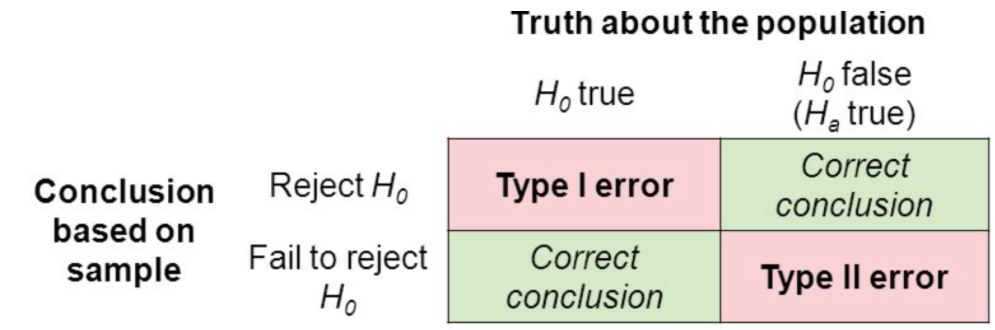

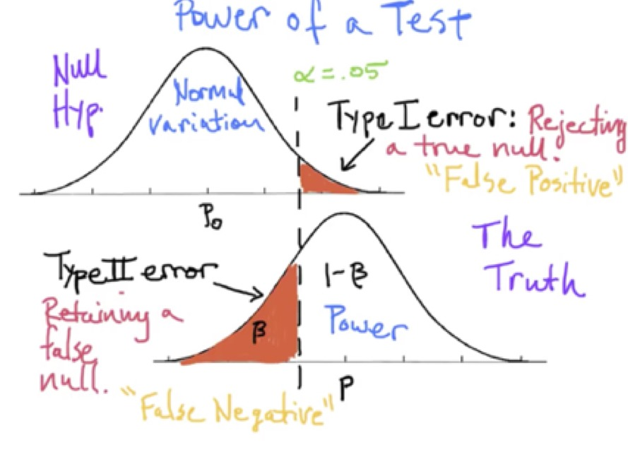

$$ \begin{aligned} &\mathrm{P}(\text { Type I error })=\alpha \equiv \text{Size of the test}\\ &\mathrm{P}(\text { Type II error })=\beta = 1 \text { - Power } \end{aligned} $$

Let's say a pregnancy test checks for a hormone level (in blood or urine): if this level is over a certain threshold then we call it "Positive" for pregnancy. If we adjust the threshold $\alpha$ to the right we may reduce the probability of making a Type-I error (false positive) but increase the probability of Type-II errors (false negative).

We can increase the power or the test by increasing the sample size which tightens the sample standard deviation

Original Comparison of Errors

Comparison of Errors with a Larger Sample Size

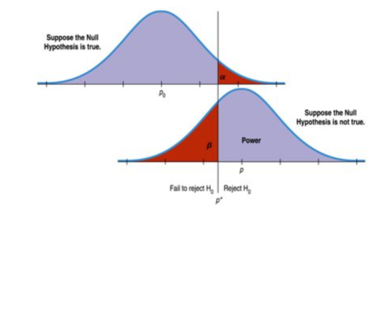

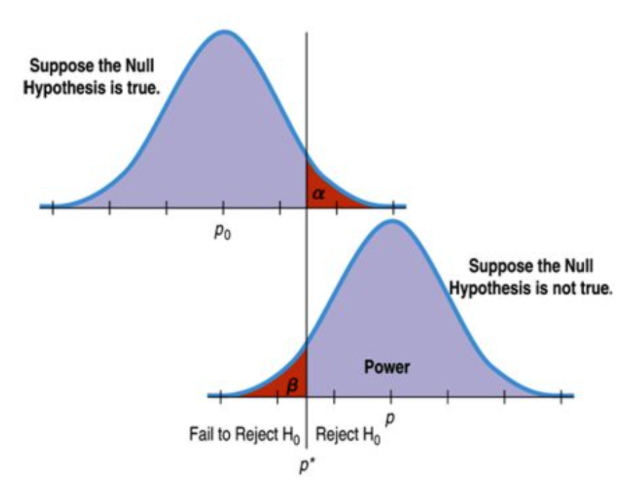

Alternately we can use a more higher powered test (i.e. test for some other hormone, ultrasound, etc.)

### Exercises

#### Exercise 1:

In a sample of 25 observations, $\bar{X}=1.63$ and $s=0.51$. Assuming $X \sim \mathcal{N}(\mu, \sigma^2)$:  
(a) Construct a 95 percent confidence interval for $\mu$ and $\sigma^2$.  
(b) Test $H_{0}: \mu=1.98$ versus $H_{a}: \mu \neq 1.98$  
(c) Test $ H_{0}: \mu \leq 1.5$ versus $H_{a}: \mu>1.5$

#### Exercise 2:

The following sample is drawn from a normal distribution with mean $\mu$ and standard deviation $\sigma$ : $$ x=1.3,2.1, .4,1.3, .5, .2,1.8,2.5,1.9,3.2 $$

Test the following hypotheses:  
(a) $\mu>2$  
(b) $\mu<.7$  
(c) $\sigma^{2}=.5$

#### Exercise 3:

A multiple regression of $y$ on a constant, $x_{1}$, and $x_{2}$ produces the following results: $$ \begin{array}{r} \hat{y}=4+0.4 x_{1}+0.9 x_{2}, R^{2}=8 / 60, \mathbf{e}^{\prime} \mathbf{e}=520, n=29, \\ \end{array} $$ $$ \mathbf{X}^{\prime} \mathbf{X}=\left[ \begin{array}{ccc} 29 & 0 & 0 \\ 0 & 50 & 10 \\ 0 & 10 & 80 \end{array} \right] $$ Test $H_{0}: \beta_1=0$ versus $H_{a}: \beta_1 \neq 0$